```python
import pySensor
from pylab import *
import os
import matplotlib
%load_ext autoreload
%autoreload 2
%matplotlib inline
#default plotting parameters
params = {'legend.fontsize': 12,
          'figure.figsize': (12, 6),
         'axes.labelsize': 18,
         'axes.titlesize': 20,
         'xtick.labelsize':12,
         'ytick.labelsize':12,
         'lines.linewidth':2}
matplotlib.rcParams.update(params)
```

# User Inputs

```python
Donor_Name='CFP'
Acceptor_Name='YFP'
FRET_Standard_Name='Tandem'
Donor_QY=.4
Acceptor_QY=.6
Excitation_1=405
Excitation_2=458
Emission_Start=416
Emission_End=718
Emission_Channels=32
Interpolation=[250,250]    #False for no interpolation
Register_to_Ex1=False      #True if masks are drawn using excitation 1 images
Central_Tendency='median'  #'mean' can also be used
```

# Initialize Calibration Object

Keyword Arguments:

> D_name=string: Donor Fluorophore Name

> A_name=string: Acceptor Fluorophore Name

> FS_name=string: Name of the FRET standard or other known 1:1 tandem construct

> Qd=float: Quantum yield of the Donor Fluorophore

> Qa=float: Quantum yield of the Acceptor Fluorophore

> ex1=int: wavelength of the laser used for the first excitation image

> ex2=int: wavelength of the laser used for the second excitation image

> multicomp=boolean: option for using separate fluorophore fitting components for excitation 1 and 2 (needed if the component shapes appreciably change between the excitation frequencies, physically the emission should be independent of excitation but external factors such as the filtersets used can modify the shape)

> em_start=int: wavelength for the first emission channel

> em_stop=int: wavelength for the last emission channel

> em_channels=int: number of emission channels

```python
C=pySensor.FRET_Calib(D_name=Donor_Name,A_name=Acceptor_Name,FS_name=FRET_Standard_Name,
                      Qd=Donor_QY,Qa=Acceptor_QY,ex1=Excitation_1,ex2=Excitation_2,
                      em_start=Emission_Start,em_stop=Emission_End,em_channels=Emission_Channels)
```

# Parse Directory Names and Save for reading .tifs and Plotting Methods

The following cell recursively reads directories in 'Grouped Tiffs' folder to get all the image filenames for importing

Directories must be structured as such:

> Calibration Inputs

> > Acceptor

> > > Frequency 1

> > > > F1 tifs (multi channel spectral images)

> > > Frequency 2

> > > > F2 tifs (multi channel spectral images)

> > > Masks

> > > > Mask tifs (single channel binary images)

> > AutoF

> > > ...

> > Donor

> > > ...

> > Tandem Construct

> > > ...

Keyword Arguments:

> 'print_names=True' prints the names of all images for you to check

```python
C.get_nested_subdirectories(print_names=True)
```

```
CTRL-YFP-405-01.tif
CTRL-YFP-405-02.tif
CTRL-YFP-405-03.tif
CTRL-YFP-405-04.tif
CTRL-YFP-405-05.tif
CTRL-YFP-405-06.tif
CTRL-YFP-458-01.tif
CTRL-YFP-458-02.tif
CTRL-YFP-458-03.tif
CTRL-YFP-458-04.tif
CTRL-YFP-458-05.tif
CTRL-YFP-458-06.tif
Mask_CTRL-YFP-458-01.tif
Mask_CTRL-YFP-458-02.tif
Mask_CTRL-YFP-458-03.tif
Mask_CTRL-YFP-458-04.tif
Mask_CTRL-YFP-458-05.tif
Mask_CTRL-YFP-458-06.tif
CTRL-DOX-405-01.tif
CTRL-DOX-405-02.tif
CTRL-none-405-01.tif
CTRL-none-405-02.tif
CTRL-DOX-458-01.tif
CTRL-DOX-458-02.tif
CTRL-none-458-01.tif
CTRL-none-458-02.tif
Mask_CTRL-DOX-458-01.tif
Mask_CTRL-DOX-458-02.tif
Mask_CTRL-none-458-01.tif
Mask_CTRL-none-458-02.tif
CTRL-CFP-405-01.tif
CTRL-CFP-405-02.tif
CTRL-CFP-405-03.tif
CTRL-CFP-458-01.tif
CTRL-CFP-458-02.tif
CTRL-CFP-458-03.tif
Mask_CTRL-CFP-458-01.tif
Mask_CTRL-CFP-458-02.tif
Mask_CTRL-CFP-458-03.tif
CTRL-CFP-YFP-405-01.tif
CTRL-CFP-YFP-405-02.tif
CTRL-CFP-YFP-405-03.tif
CTRL-CFP-YFP-405-04.tif
CTRL-CFP-YFP-405-05.tif
CTRL-CFP-YFP-458-01.tif
CTRL-CFP-YFP-458-02.tif
CTRL-CFP-YFP-458-03.tif
CTRL-CFP-YFP-458-04.tif
CTRL-CFP-YFP-458-05.tif
Mask_CTRL-CFP-YFP-458-01.tif
Mask_CTRL-CFP-YFP-458-02.tif
Mask_CTRL-CFP-YFP-458-03.tif
Mask_CTRL-CFP-YFP-458-04.tif
Mask_CTRL-CFP-YFP-458-05.tif
```

# All Image Data is Read into Calibration Object

All spectral images, Masks1, and Masks2 data is read into the tif_array attribute of FRET_Calib.

```python
C.get_tif_container(interpolation=Interpolation)
```

# Register Images

```python
C.register_images(to_F1=Register_to_Ex1)
```

```
('Y: 57.000', 'X: -26.000')
Register using this large registration shift? (True or False)False
('Y: 0.000', 'X: 0.000')
('Y: 0.000', 'X: 0.000')
('Y: 0.000', 'X: 0.000')
('Y: 0.000', 'X: 0.000')
('Y: 0.000', 'X: 0.000')
_____________
('Y: 0.000', 'X: 0.000')
('Y: 0.000', 'X: 0.000')
('Y: 0.000', 'X: 0.000')
('Y: 0.000', 'X: 0.000')
_____________
('Y: 0.000', 'X: 0.000')
('Y: 0.000', 'X: 0.000')
('Y: 0.000', 'X: 0.000')
_____________
('Y: 0.000', 'X: 0.000')
('Y: 0.000', 'X: 0.000')
('Y: 0.000', 'X: 0.000')
('Y: 0.000', 'X: 0.000')
('Y: 0.000', 'X: 0.000')
_____________
```

# Sort Image Data

This step sorts only the masked pixels and labels each pixel spectra with which group, image, and region it is part of along with its x and y location. Since the masked regions are typically small compared to the whole image this greatly reduces the file size and memory usage because all of the pixels outside of the mask dont need to be saved.

```python
C.sort_tif_container(central_tendency=Central_Tendency)
C.group_DF.T
```

```
Total Pixels: 16756
Total Regions: 53
Total Images: 18
Total Groups: 4
```

|  | 0 | 1 | 2 | 3 |
| --- | --- | --- | --- | --- |
| label | Acceptor | AutoF | Donor | FRET_Standard |
| area | 2554 | 9600 | 1303 | 3299 |
| group | 0 | 1 | 2 | 3 |
| image | 6 | 4 | 3 | 5 |
| region | 13 | 4 | 15 | 21 |
| spectra1 | [197.173210144, 268.385559082, 313.518234253, ... | [141.710380554, 106.287181854, 134.276649475, ... | [187.061828613, 281.304382324, 730.529174805, ... | [238.352325439, 258.960601807, 391.210083008, ... |
| spectra2 | [134.69417572, 100.857456207, 117.274360657, 1... | [133.17943573, 83.7487373352, 106.709117889, 1... | [129.119674683, 116.286872864, 426.604644775, ... | [141.658157349, 102.713951111, 184.631225586, ... |
| x_loc | 128 | 120 | 166 | 160 |
| y_loc | 121 | 112 | 170 | 146 |

# Create Calibration Components:

Using the average of all pixels, unmixing components are generated for both excitation frequencies. The plot below shows the components that will be saved in the calibration file used to unmix experimental spectra.

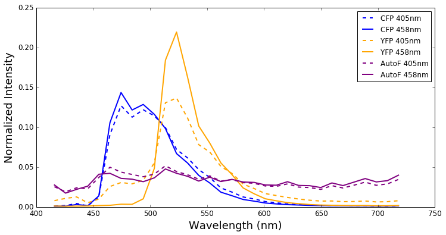

```
Fit using excitation dependent components? (True or False) False
Which excitation should determine donor shape? (1=405nm,2=458nm) 2
Which excitation should determine acceptor shape? (1=405nm,2=458nm) 2
```

```python
C.create_components()
```

```python
#C.remCompChannels(ex=1,component='AutoF',ind=[1,2])
#C.remCompChannels(ex=2,component='none',ind=[1,2])
```

# Unmix DataFrames

Sort tif container creates four different observation DataFrames. The unmix_DF method will apply the SensorFRET algorithm to each observation in all four DataFrames. This may take several few minutes to complete

```python
C.unmix_DF(observation='all')
C.group_DF.T
```

|  | 0 | 1 | 2 | 3 |
| --- | --- | --- | --- | --- |
| label | Acceptor | AutoF | Donor | FRET_Standard |
| area | 2554 | 9600 | 1303 | 3299 |
| group | 0 | 1 | 2 | 3 |
| image | 6 | 4 | 3 | 5 |
| region | 13 | 4 | 15 | 21 |
| spectra1 | [197.173210144, 268.385559082, 313.518234253, ... | [141.710380554, 106.287181854, 134.276649475, ... | [187.061828613, 281.304382324, 730.529174805, ... | [238.352325439, 258.960601807, 391.210083008, ... |
| spectra2 | [134.69417572, 100.857456207, 117.274360657, 1... | [133.17943573, 83.7487373352, 106.709117889, 1... | [129.119674683, 116.286872864, 426.604644775, ... | [141.658157349, 102.713951111, 184.631225586, ... |
| x_loc | 128 | 120 | 166 | 160 |
| y_loc | 121 | 112 | 170 | 146 |
| D_D1 | 5656.88 | -5.21585e-13 | 154227 | 67358.2 |
| D_AF1 | 20925.5 | 5591.45 | 15011.9 | 109929 |
| D_R1 | 0.165406 | 2.66676e-17 | 0.022824 | 0.184301 |
| D_D2 | 33059.1 | 0 | 138466 | 75812.7 |
| D_AF2 | 92421.1 | 4837.3 | 2.37735e-11 | 94007.4 |
| D_R2 | 0.291817 | 2.34677e-17 | 1.22928e-16 | 0.214559 |
| A_A1 | 14457.5 | -3.87786e-13 | 28001.3 | 109584 |
| A_AF1 | 10865.6 | 5591.45 | 165558 | 62730.4 |
| A_R1 | 0.0321041 | 3.33561e-17 | 0.19464 | 0.0639781 |
| A_A2 | 114191 | -5.68581e-13 | 25502.3 | 124265 |
| A_AF2 | -1.43448e-11 | 4837.3 | 120177 | 36228 |
| A_R2 | 1.03561e-16 | 1.64882e-17 | 0.232755 | 0.0619132 |
| F_D1 | 2774.41 | -5.13132e-13 | 152010 | 46084.9 |
| F_A1 | 14145 | -4.14839e-14 | 10878.8 | 104393 |
| F_AF1 | 7935.54 | 5591.45 | 5021.49 | 14060.3 |
| F_R1 | 0.0214155 | 2.65808e-17 | 0.0130955 | 0.0220591 |
| F_D2 | 6.10636e-12 | -3.87831e-14 | 138466 | 42080.8 |
| F_A2 | 114191 | -5.61438e-13 | -3.74719e-12 | 116515 |
| F_AF2 | -1.96446e-11 | 4837.3 | 2.68063e-11 | -294.435 |
| F_R2 | 1.0281e-16 | 1.63822e-17 | 1.22674e-16 | 0.00378282 |
| I1 | 24991.8 | 5591.45 | 168642 | 165330 |
| I2 | 114191 | 4837.3 | 138466 | 158494 |

```python
C.default_calculations()
C.group_DF.T
```

```
Gamma: 0.113669775716
eD/eA (freq1): 57.2982608387
eD/eA (freq2): 6.51308045844
```

|  | 0 | 1 | 2 | 3 |
| --- | --- | --- | --- | --- |
| label | Acceptor | AutoF | Donor | FRET_Standard |
| area | 2554 | 9600 | 1303 | 3299 |
| group | 0 | 1 | 2 | 3 |
| image | 6 | 4 | 3 | 5 |
| region | 13 | 4 | 15 | 21 |
| spectra1 | [197.173210144, 268.385559082, 313.518234253, ... | [141.710380554, 106.287181854, 134.276649475, ... | [187.061828613, 281.304382324, 730.529174805, ... | [238.352325439, 258.960601807, 391.210083008, ... |
| spectra2 | [134.69417572, 100.857456207, 117.274360657, 1... | [133.17943573, 83.7487373352, 106.709117889, 1... | [129.119674683, 116.286872864, 426.604644775, ... | [141.658157349, 102.713951111, 184.631225586, ... |
| x_loc | 128 | 120 | 166 | 160 |
| y_loc | 121 | 112 | 170 | 146 |
| D_D1 | 5656.88 | -5.21585e-13 | 154227 | 67358.2 |
| D_AF1 | 20925.5 | 5591.45 | 15011.9 | 109929 |
| D_R1 | 0.165406 | 2.66676e-17 | 0.022824 | 0.184301 |
| D_D2 | 33059.1 | 0 | 138466 | 75812.7 |
| D_AF2 | 92421.1 | 4837.3 | 2.37735e-11 | 94007.4 |
| D_R2 | 0.291817 | 2.34677e-17 | 1.22928e-16 | 0.214559 |
| A_A1 | 14457.5 | -3.87786e-13 | 28001.3 | 109584 |
| A_AF1 | 10865.6 | 5591.45 | 165558 | 62730.4 |
| A_R1 | 0.0321041 | 3.33561e-17 | 0.19464 | 0.0639781 |
| A_A2 | 114191 | -5.68581e-13 | 25502.3 | 124265 |
| A_AF2 | -1.43448e-11 | 4837.3 | 120177 | 36228 |
| A_R2 | 1.03561e-16 | 1.64882e-17 | 0.232755 | 0.0619132 |
| F_D1 | 2774.41 | -5.13132e-13 | 152010 | 46084.9 |
| F_A1 | 14145 | -4.14839e-14 | 10878.8 | 104393 |
| F_AF1 | 7935.54 | 5591.45 | 5021.49 | 14060.3 |
| F_R1 | 0.0214155 | 2.65808e-17 | 0.0130955 | 0.0220591 |
| F_D2 | 6.10636e-12 | -3.87831e-14 | 138466 | 42080.8 |
| F_A2 | 114191 | -5.61438e-13 | -3.74719e-12 | 116515 |
| F_AF2 | -1.96446e-11 | 4837.3 | 2.68063e-11 | -294.435 |
| F_R2 | 1.0281e-16 | 1.63822e-17 | 1.22674e-16 | 0.00378282 |
| I1 | 24991.8 | 5591.45 | 168642 | 165330 |
| I2 | 114191 | 4837.3 | 138466 | 158494 |
| D_ratio | 0.171114 | -inf | 1.11382 | 0.888482 |
| A_ratio | 0.126608 | 0.682025 | 1.09799 | 0.881857 |
| Ind1 | 5.09837 | 0.0808446 | 0.0715662 | 2.26523 |
| Ind2 | 1.87004e+16 | 14.4763 | -2.70621e-17 | 2.76883 |
| Alpha | 2.20096e-15 | 0.0755812 | 0.910904 | 0.913116 |
| Beta | 114191 | -5.58303e-13 | -9909.5 | 21192 |
| A_dir1 | 6.65381e+18 | -9.47339e-13 | -1395.18 | 2976.42 |
| A_dir2 | 128836 | -6.29904e-13 | -11180.4 | 23909.8 |
| Eff | 1 | 6.65301 | 0.05108 | 0.594665 |
| eD_eA1 | -1 | -0.143726 | -172.228 | 57.2983 |
| eD_eA2 | -0.11367 | -0.0163373 | -19.5772 | 6.51308 |
| S | -0.0174525 | -0.00250838 | -3.00582 | 1 |
| Eff_S | -0.0174525 | -0.0166883 | -0.153537 | 0.594665 |

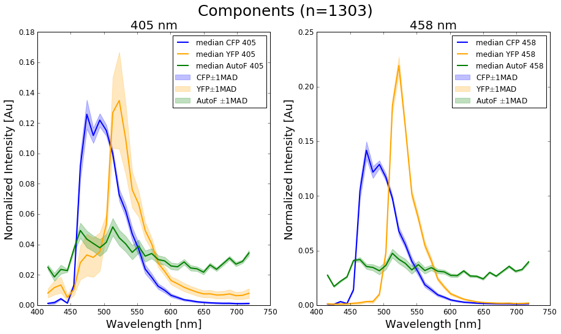

```python
C.plotComps(observation='pixel',specify=[],colors=[],update_values=False)
```

```
D2/D1: 0.874165850417
A1/A2: 0.122031179818
Gamma: 0.106675490083
```

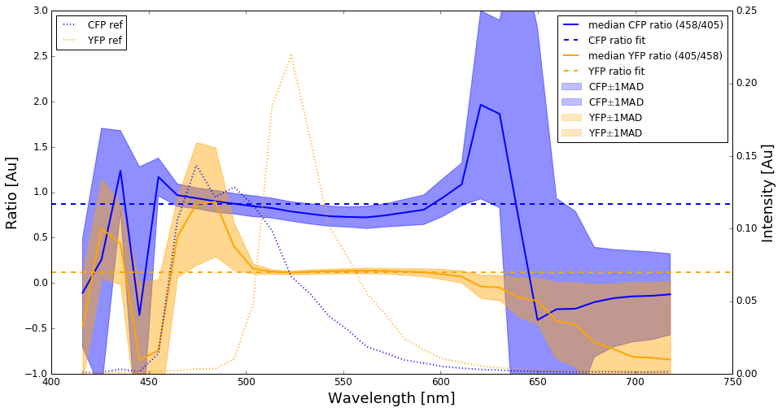

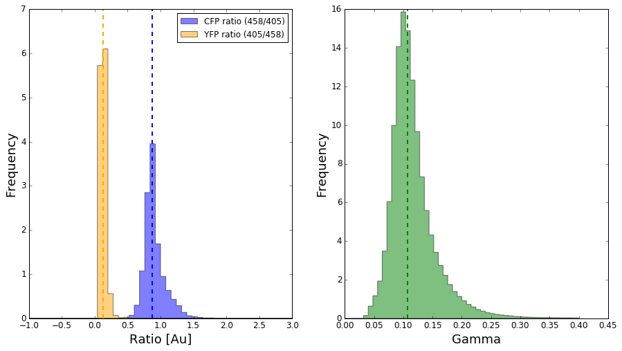

```python
C.plotGamma(observation='pixel',specify=[],colors=[],
            spec_range=(-1,3),g_range=(0,.4),ratio_range=(-1,3),update_values=False)
```

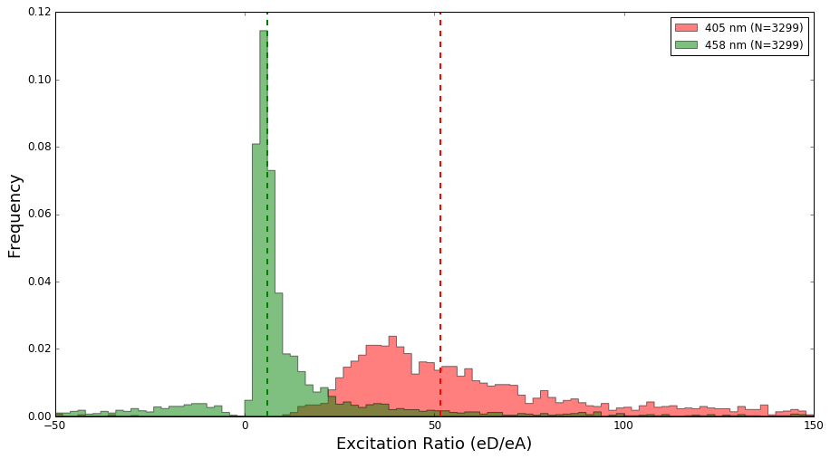

```
Excitation Ratio (405 nm):51.5128279182
Excitation Ratio (458 nm):5.85545159595
```

```python
C.plotExRatios(observation='pixel',specify=[],colors=[],
               ratio_range=(-50,150),bins=100,update_values=False)
```

```
Getting Figure Sets
---------------------------------------------------------------------------------

Generating Plots
---------------------------------------------------------------------------------
```

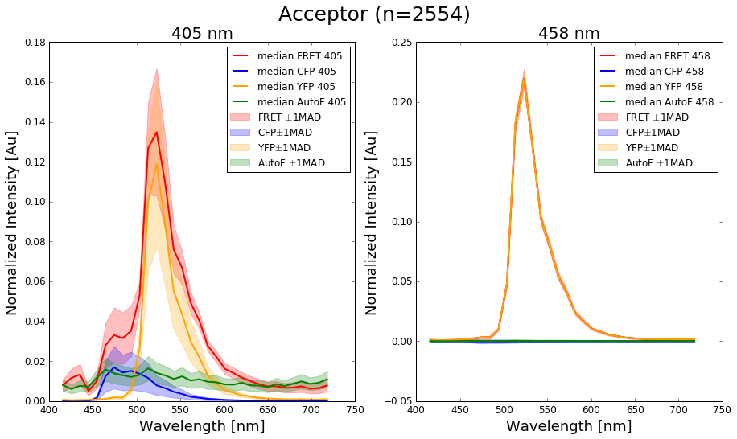

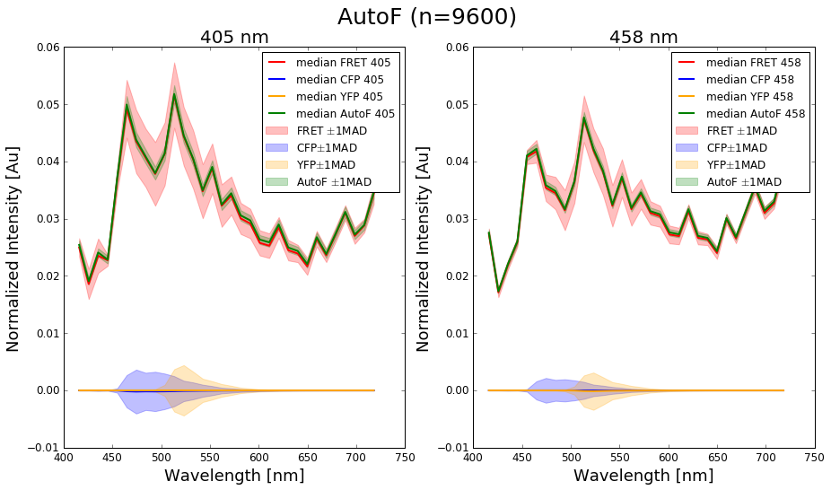

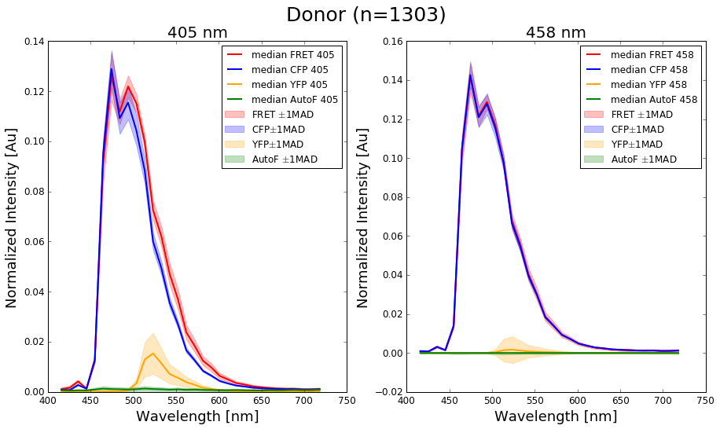

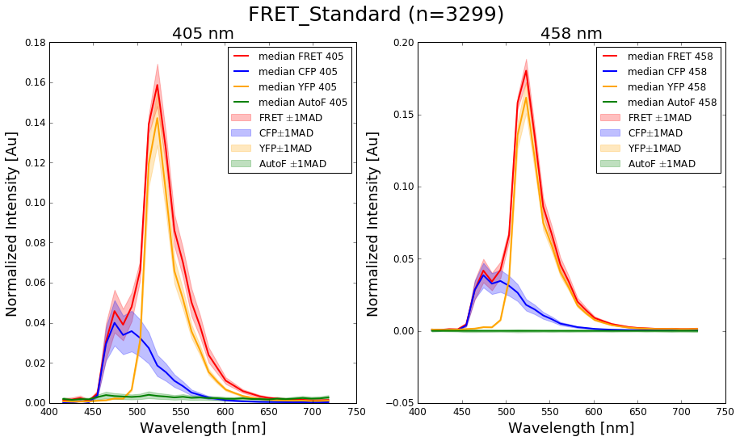

```python
C.spectraFit(norm=True,observation='pixel',plot_by='group',specify=[])
```

```
Getting Figure Sets
---------------------------------------------------------------------------------

Generating Plots
---------------------------------------------------------------------------------
```

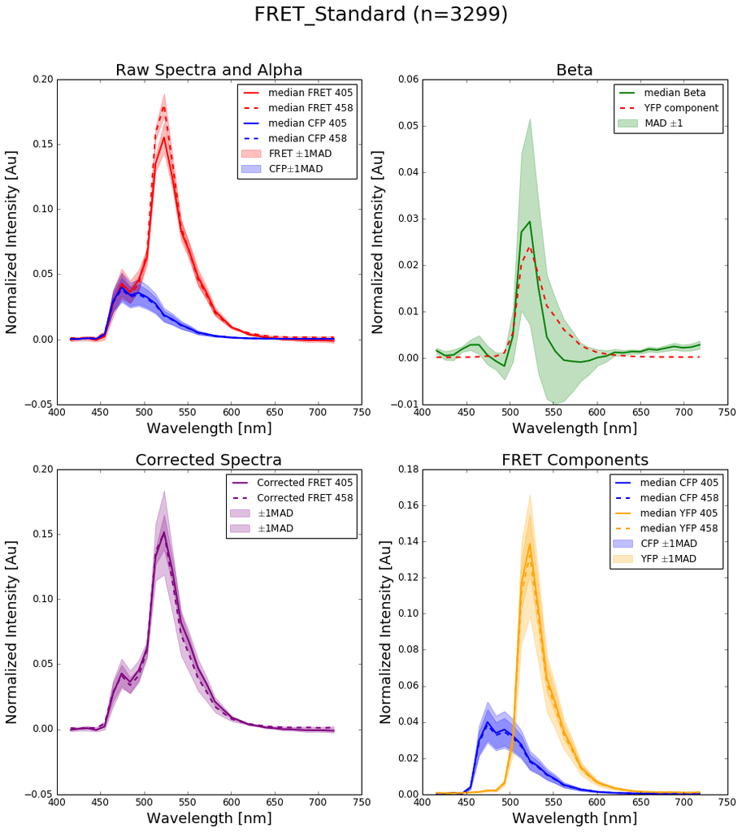

```python
C.plotFRETvariance(observation='pixel',plot_by='group', specify=[['group','=',[3]]])
```

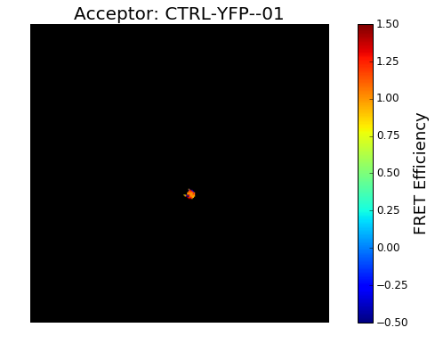

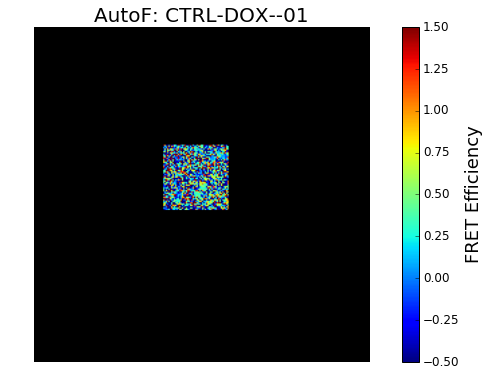

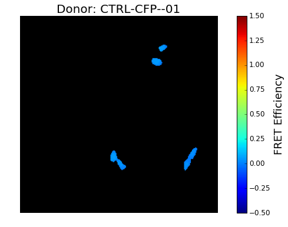

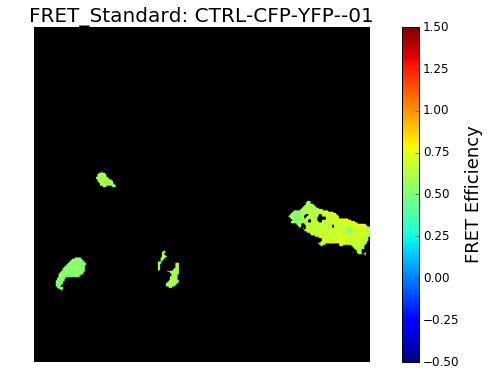

```python
C.showImage(param='Eff',ex=2,mn=-.5,mx=1.5,specify=[['image','=',[0]]])
```

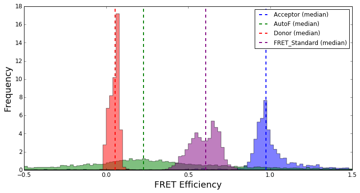

```python
C.plotHistogram(param='Eff',ex=2,lim_x=[-.5,1.5],bins=100,norm=True,
                      observation='pixel',plot_by='group',specify=[],colors=[])
```

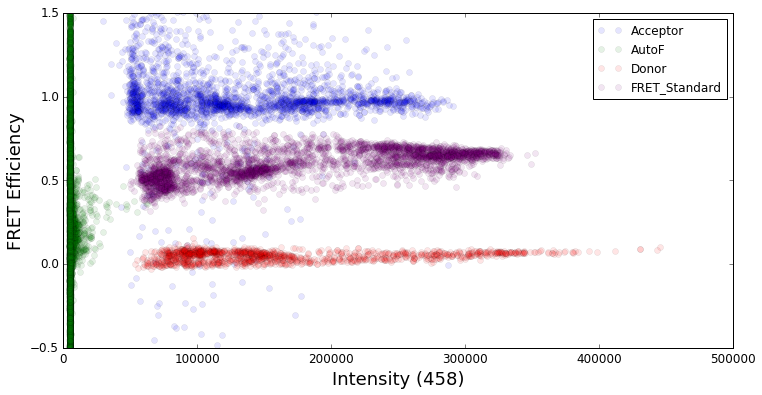

```python
C.plotScatter(param_x='I',ex_x=2,param_y='Eff',ex_y=2,
                    lim_x=[0,5e5],lim_y=[-.5,1.5],observation='pixel',plot_by='group',
                    specify=[],colors=[],alpha=.1,fit=False,print_fit=False)
```

```python
C.boxplot(param='Eff',ex=2,observation='pixel',plot_by='group',
                lim_y=[-.5,1.5],specify=[],colors=[],rotate_labels=90)
```

[output not shown]

```python
C.significance(param='Eff',ex=2,observation='pixel',plot_by='group',
                threshold=.05,test="Mann-Whitney U Test",print_pval=False,specify=[],colors=[])
```

[output not shown]

```python
C.create_calibration_DF(to_xlsx=True)
```

# Export .html file

The code in the following cell is based on Mac OSX commands and may need to be adjusted to work in Windows (mv=move in windows, etc)

```python
export_command='jupyter nbconvert --to html pySensor_Calibration.ipynb'
rename_command='mv pySensor_Calibration.html CalibrationFiles/Calibration_xlsx/'+C.CalibName+'.html'
os.system(export_command)
os.system(rename_command)
```